# [Заметки по R](http://bdemeshev.github.io/r_cycle/): Мультиколлинеарность

24.03.2016

Загружаем нужные пакеты:

```r
library("knitr") # создание отчётов
# opts_chunk$set(cache=TRUE)

library("ggplot2") # графики
library("glmnet") # LASSO
library("car") # compute vif()
library("MASS") # ridge regression
library("quantreg") # quantile regression
```

Возьмем встроенные в R данные по скорости автомобилей и длине тормозного пути. Это данные 1920-х годов. Скорость в милях в час, миля — это примерно $1.61$ километра. Длина тормозного пути — в футах. Один фут — это примерно $30$ сантиметров.

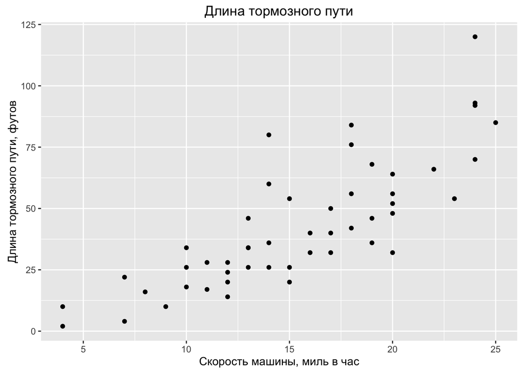

```r
ggplot(data = cars, aes(x = speed, y = dist)) + geom_point() +
  labs(x = "Скорость машины, миль в час",
       y = "Длина тормозного пути, футов",
       title = "Длина тормозного пути")
```

Построим полиномиальную регрессию тормозного пути от скорости:

```r
m.poly3 <- lm(dist ~ speed + I(speed^2) + I(speed^3), data = cars)
```

Предвосхищаем вопрос: Что значит `I(...)`? Буква `I` со скобками заставляет R воспринимать выражение внутри скобок в естественном математическом смысле, а не в специальном “регрессионном” смысле. Например:

- `y ~ x + z` — регрессия $y$ на $x$ и $z$
- `y ~ I(x + z)` — регрессия $y$ на одну переменную $x+z$
- `y ~ (x + z + w)^2` — регрессия $y$ на $x$, $z$, $w$ и все попарные произведения, т.е. на $xz$, $xw$ и $wz$.
- `y ~ I((x + z + w)^2)` — регрессия на одну переменную $(x+z+w)^2$
- `y ~ (x + z + w)^3` — регрессия $y$ на $x$, $z$, $w$, $xz$, $xw$, $zw$, $xzw$
- `y ~ I((x + z + w)^3)` — регрессия на одну переменную $(x+z+w)^3$

Смотрим на отчёт по регрессии:

```r
summary(m.poly3)
```

```
##
## Call:
## lm(formula = dist ~ speed + I(speed^2) + I(speed^3), data = cars)
##
## Residuals:
##     Min      1Q  Median      3Q     Max
## -26.670  -9.601  -2.231   7.075  44.691
##
## Coefficients:
##              Estimate Std. Error t value Pr(>|t|)
## (Intercept) -19.50505   28.40530  -0.687    0.496
## speed         6.80111    6.80113   1.000    0.323
## I(speed^2)   -0.34966    0.49988  -0.699    0.488
## I(speed^3)    0.01025    0.01130   0.907    0.369
##
## Residual standard error: 15.2 on 46 degrees of freedom
## Multiple R-squared:  0.6732, Adjusted R-squared:  0.6519
## F-statistic: 31.58 on 3 and 46 DF,  p-value: 3.074e-11
```

Мы видим, что:

- ни один коэффициент не значим
- регрессия в целом значима

Это один из признаков мультиколлинеарности.

Мультиколлинеарность — ситуация, когда все предпосылки теоремы Гаусса-Маркова выполнены, но дисперсия оценок является слишком высокой по твоему мнению

Другие признаки мультиколлинеарности:

- Нестабильность коэффициентов при удалении одного наблюдения;
- Высокие корреляции регрессоров;
- Показатели в духе VIF и CI.

Корреляционная матрица регрессоров:

```r
X <- model.matrix(~ 0 + speed + I(speed^2) + I(speed^3), data = cars)
cor(X)
```

```
##                speed I(speed^2) I(speed^3)
## speed      1.0000000  0.9794765  0.9389237
## I(speed^2) 0.9794765  1.0000000  0.9884061
## I(speed^3) 0.9389237  0.9884061  1.0000000
```

Расчитаем индекс обусловленности, condition index,
$$CI=\sqrt{\frac{\lambda_{max}}{\lambda_{min}}}$$
где $\lambda$ — собственное число матрицы $X'X$.

Вроде бы в некоторых источниках считают собственные числа у корреляционной или ковариационной матрицы регрессоров (???) (Лена Вакуленко) (Некоторые источники не указаны несколько дней. Вы можете улучшить эту статью :)

```r
X <- model.matrix( ~ speed + I(speed^2) + I(speed^3), data = cars)
XX <- t(X) %*% X
eigen <- eigen(XX)
eigen$values
```

```
## [1] 2.080900e+09 1.586193e+05 7.315488e+01 2.719130e-01
```

```r
CI <- sqrt(max(eigen$values) / min(eigen$values))
CI
```

```
## [1] 87480.38
```

Наверняка есть пакет, в котором CI уже реализован. Но иногда дольше искать нужный пакет, чем написать функцию самому. Тем более тут нагляднее формула видна.

Википедия говорит, что $CI>30$ признак мультиколлинеарности. Но это не строгая граница. Мультиколлинеарность — это субъективное недовольство высокими стандартными ошибками коэффициентов.

Рассчитаем коэффициент вздутия дисперсии, variance inflation factor
$$VIF_j=\frac{1}{1-R_j^2}$$
где $R_j^2$ — это коэффициент $R^2$ в регрессии $j$-ой объясняющей переменной на остальные.

Популярная граница для VIF — 10. У нас:

```r
vif(m.poly3)
```

```
##      speed I(speed^2) I(speed^3)
##   274.1131  1408.0884   483.0570
```

NB: нужно уметь рассчитывать vif ручками, зная коэффициенты R^2 во вспомогательных регрессиях. Например:

```r
m.vif1 <- lm(speed ~ I(speed^2) + I(speed^3), data = cars)
r2.1 <- summary(m.vif1)$r.squared
vif1 <- 1 / (1 - r2.1)
vif1
```

```
## [1] 274.1131
```

## Забудем про имеющуюся мультиколлинеарностьи попробуем заняться прогнозированием…

Из модели можно вытащить ковариационную матрицу оценок коэффициентов

```r
vcov(m.poly3)
```

```
##              (Intercept)         speed   I(speed^2)    I(speed^3)
## (Intercept)  806.8612229 -186.19855321 12.875757330 -0.2736117808
## speed       -186.1985532   46.25543452 -3.346993631  0.0733088858
## I(speed^2)    12.8757573   -3.34699363  0.249882783 -0.0055981567
## I(speed^3)    -0.2736118    0.07330889 -0.005598157  0.0001276477
```

Можно построить прогноз длины тормозного пути для машины с скоростью $speed=10$ миль в час.

```r
new <- data.frame(speed = 10)
predict(m.poly3, newdata=new, interval = 'confidence')
```

```
##        fit     lwr      upr
## 1 23.79228 15.8941 31.69045
```

Если нужно вытащить стандартную ошибку для $\hat{y}$, то можно внутрь команды `predict` добавить опцию `se.fit=TRUE`.

На всякий случай, есть два типа доверительных интервалов при прогнозировании. Доверительный интервал для мат. ожидания будущего игрека — опция `'confidence'` в R. И прогнозный интервал для индивидуального значения игрека — опция `'prediction'` в R.

Попробуем перейти к центированным переменным.

```r
cars$spc <- cars$speed - mean(cars$speed)
m.poly3c <- lm(dist ~ spc + I(spc^2) + I(spc^3), data = cars)
summary(m.poly3c)
```

```
##
## Call:
## lm(formula = dist ~ spc + I(spc^2) + I(spc^3), data = cars)
##
## Residuals:
##     Min      1Q  Median      3Q     Max
## -26.670  -9.601  -2.231   7.075  44.691
##
## Coefficients:
##             Estimate Std. Error t value Pr(>|t|)
## (Intercept) 39.75032    2.86281  13.885  < 2e-16 ***
## spc          3.32577    0.84227   3.949 0.000268 ***
## I(spc^2)     0.12399    0.07120   1.741 0.088298 .
## I(spc^3)     0.01025    0.01130   0.907 0.368919
## ---
## Signif. codes:  0 '***' 0.001 '**' 0.01 '*' 0.05 '.' 0.1 ' ' 1
##
## Residual standard error: 15.2 on 46 degrees of freedom
## Multiple R-squared:  0.6732, Adjusted R-squared:  0.6519
## F-statistic: 31.58 on 3 and 46 DF,  p-value: 3.074e-11
```

Вау! Теперь появились значимые коэффициенты!!!!!

Но это всего лишь иллюзия. У этих оценок коэффициентов другая ковариационная матрица.

```r
vcov(m.poly3c)
```

```
##              (Intercept)          spc     I(spc^2)      I(spc^3)
## (Intercept)  8.195662560  0.325738550 -0.134011045 -0.0061108467
## spc          0.325738550  0.709415046 -0.016836556 -0.0082955869
## I(spc^2)    -0.134011045 -0.016836556  0.005069365  0.0002991650
## I(spc^3)    -0.006110847 -0.008295587  0.000299165  0.0001276477
```

И если построить доверительный интервал для прогнозов, то ничего не изменится.

```r
new$spc <- 10 - mean(cars$speed)
predict(m.poly3c, newdata = new, interval = 'confidence')
```

```
##        fit     lwr      upr
## 1 23.79228 15.8941 31.69045
```

Модель с центрированными переменными — это всего лишь по-другому записанная исходная модель.

Кстати, нужно уметь строить доверительный интервал для прогноза “ручками” имея на руках оценки коэффициентов и оценку ковариационной матрицы.

## Как же бороться с мультиколлинеарностью?

- Смириться с высокими стандартными ошибками. Высокие? Ну и чёрт с ними!
- Увеличить количество наблюдений.
- Задать другой вопрос.

“I checked it very thoroughly,” said the computer, “and that quite definitely is the answer. I think the problem, to be quite honest with you, is that you’ve never actually known what the question is.”

Douglas Adams, Hitchhiker’s Guide to the Galaxy.

Обычная регрессия отвечает на такой вопрос:

Чему равны несмещенные оценки с наименьшей дисперсией в модели $E(y)=\beta_1+\beta_2 x +\beta_3 z$?

Можно задаться целью получить смещенные оценки. Почему нам интересны смещенные оценки? Дао учит нас, что любая смещенная оценка коэффициента $\beta$ есть несмещенная оценка какого-то коэффициента $\gamma$.

Поэтому можно:

- Убрать из регрессии некоторые переменные
- В частности, можно оставить в регрессии “главные компоненты”, искусственные переменные, которые содержат большую часть информации обо всех исходных переменных
- При минимизации RSS ввести штраф за слишком большие коэффициенты $\hat{\beta}$. Два популярных способа ввести штраф — Ridge Regression и LASSO
- Выяснить как зависит медиана (или другой квантиль $y$) от объясняющих переменных

## Убрать из регрессии некоторые переменные

В регрессии $y$ на $x$ и $z$ коэффициент при $x$ показывает насколько изменится $y$ при изменении $x$ на единичку и фиксированном $z$. В регрессии $y$ на $x$ коэффициент при $x$ показывает насколько изменится $y$ при изменении $x$ на единичку и нефиксированном $z$.

```r
m.line <- lm(dist ~ speed, data = cars)
summary(m.line)
```

```
##
## Call:
## lm(formula = dist ~ speed, data = cars)
##
## Residuals:
##     Min      1Q  Median      3Q     Max
## -29.069  -9.525  -2.272   9.215  43.201
##
## Coefficients:
##             Estimate Std. Error t value Pr(>|t|)
## (Intercept) -17.5791     6.7584  -2.601   0.0123 *
## speed         3.9324     0.4155   9.464 1.49e-12 ***
## ---
## Signif. codes:  0 '***' 0.001 '**' 0.01 '*' 0.05 '.' 0.1 ' ' 1
##
## Residual standard error: 15.38 on 48 degrees of freedom
## Multiple R-squared:  0.6511, Adjusted R-squared:  0.6438
## F-statistic: 89.57 on 1 and 48 DF,  p-value: 1.49e-12
```

## Метод главных компонент

В частности можно попытаться оставить только несколько переменных, которые “впитывают” в себя большую часть изменчивости всех исходных переменных. Этот метод называется метод главных компонент. Подробнее отдельно.

## Ridge regression

Теоретически RR позволяет при удаче получить оценки $\hat{\beta}$ с меньшей, чем у OLS величиной среднеквадратичной ошибкой, MSE.

Алгоритм Ridge regression минимизирует функцию
$$\sum_{i=1}^n (y_i-\hat{y}_i)^2+\lambda \sum_{j=1}^k \hat{\beta}_j^2$$

По сравнению с обычной регрессией введен “штраф” $\lambda$ за большие значения $\hat{\beta}_j$.

Эту задачу можно решить в явном виде:
$$\hat{\beta}_{RR}=(X'X+\lambda I)^{-1}X'y$$$

По другому RR можно сформулировать так: минимизируем обычный RSS при ограничении $\sum_{j=1}^k \hat{\beta}_j^2 \leq c$. Выписав функцию Лагранжа для этой задачи минимизации получим формулировку задачи RR с лямбдой.

Делаем RR в R :)

```r
lambdas <- seq(0.1, 10, by = 0.1) # для этих лямбд будем делать RR
m.rr <- lm.ridge(dist ~ speed + I(speed^2) + I(speed^3), lambda = lambdas, data = cars)
```

Посмотрим, как зависят оценки коэффициентов, от штрафа за высокие значения $\hat{\beta}$:

```r
head(coef(m.rr))
```

```
##                     speed   I(speed^2)  I(speed^3)
##  0.1 -3.01537827 2.527598 -0.030849757 0.003107425
##  0.2 -1.22232251 2.075884  0.002367543 0.002367979
##  0.3 -0.49028466 1.899616  0.015025886 0.002089223
##  0.4 -0.06934523 1.803796  0.021696131 0.001944379
##  0.5  0.21734664 1.742467  0.025810896 0.001856488
##  0.6  0.43327898 1.699150  0.028599871 0.001797998
```

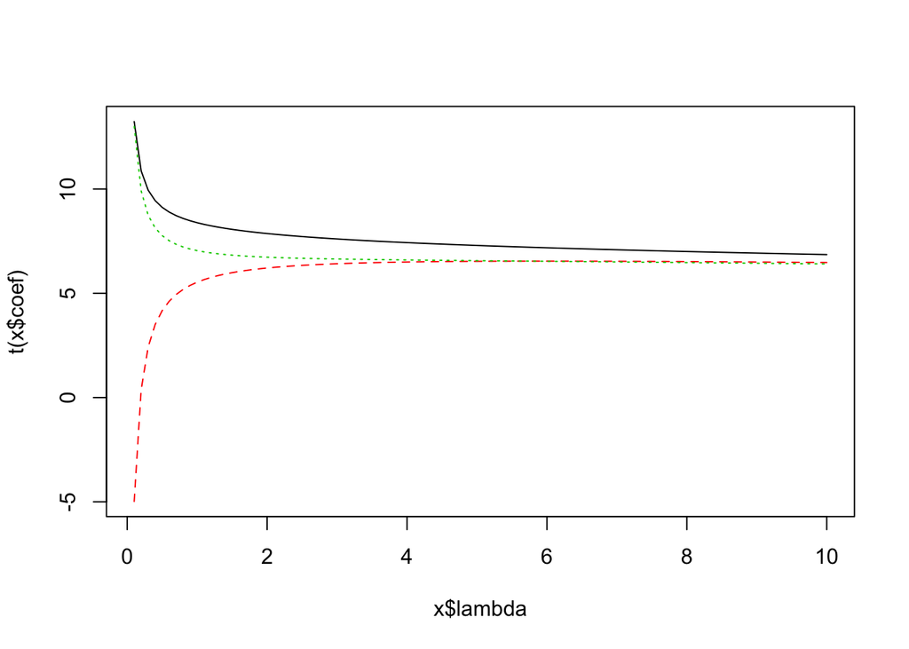

```r
plot(m.rr)
```

Не вдаваясь в подробности скажем, что есть много алгоритмов, определяющих, какой $\lambda$ выбрать. Помимо кросс-валидации популярны еще:

```r
m.rr$kHKB # оценка Hoerl, Kennard and Baldwin
```

```
## [1] 0.03674321
```

```r
m.rr$kLW # оценка Lawless and Wang
```

```
## [1] 0.527701
```

Достоинства RR: * Оценка RR всегда есть. Даже в случае жесткой мультиколлинеарности. Даже если регрессоров больше чем, наблюдений. * Теорема: существует $\lambda$, при котором $MSE(\hat{\beta}_{RR})$ строго меньше, чем $MSE(\hat{\beta}_{OLS})$. Напомню, что MSE — mean squared error, это $MSE(\hat{\beta})=E((\hat{\beta}-\beta)^2)$. Оценки $\hat{\lambda}_{HKB}$ и $\hat{\lambda}_{LW}$ пытаются поймать это неизвестное $\lambda$ минимизирующее $MSE$.

Недостатки RR: * Нужно выбирать $\lambda$. Конечно, есть куча алгоритмов, как это сделать. * Насколько мне известно, удачных методов постоения доверительных интервалов для $\beta$ нет.

## LASSO

LASSO очень похож на RR, отличие состоит в том, что в LASSO минимизируется функция
$$\sum_{i=1}^n (y_i-\hat{y}_i)^2+\lambda \sum_{j=1}^k |\hat{\beta}_j|$$

Заметим сразу, что функция “мерзкая”: в ней есть модуль, поэтому она не дифференциируема. Поэтому явной готовой формулы для $\hat{\beta}_{LASSO}$ ожидать не приходится.

По другому LASSO можно сформулировать так: минимизируем обычный RSS при ограничении $\sum_{j=1}^k |\hat{\beta}_j| \leq c$. Выписав функцию Лагранжа для этой задачи минимизации получим формулировку задачи LASSO с лямбдой.

Достоинства LASSO: * В угловых решениях некоторые $\hat{\beta}_j$ в точности оказываются равными нулю. Т.е. LASSO без всякой проверки гипотез в каком-то смысле делит коэффициенты на “существенные” и “несущественные” * Оценка LASSO всегда есть. Даже в случае жесткой мультиколлинеарности. Даже если регрессоров больше чем, наблюдений.

Недостатки LASSO: * Нужно выбирать $\lambda$. Конечно, есть куча алгоритмов, как это сделать. * Насколько мне известно, удачных методов постоения доверительных интервалов для $\beta$ нет.

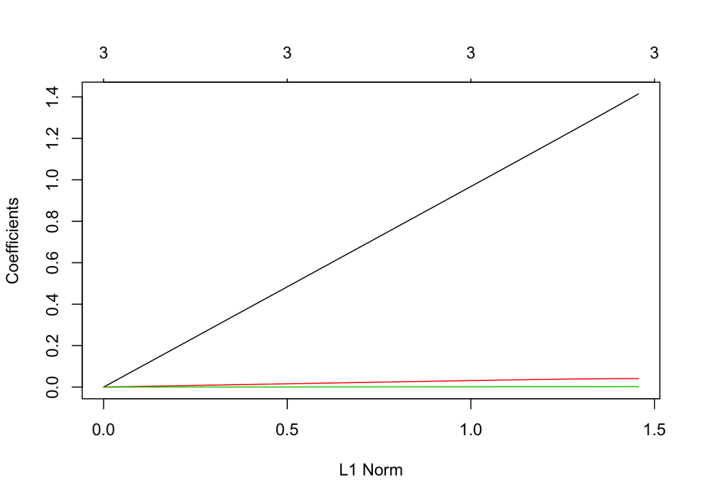

```r
X <- model.matrix(~ 0 + speed + I(speed^2) + I(speed^3), data = cars)
y <- cars$dist
fit <- glmnet(X, y, alpha = 0)
plot(fit)
```

```r
head(fit$lambda) # вектор лямбд
```

```
## [1] 20817.22 18967.88 17282.83 15747.47 14348.50 13073.82
```

```r
head(fit$a0) # вектор оценок свободных коэффициентов
```

```
##       s0       s1       s2       s3       s4       s5
## 42.98000 42.82094 42.80550 42.78857 42.77000 42.74964
```

И оценки остальных коэффициентов для каждого лямбда

```r
fit$beta[, 1:5] # покажем только первые 5
```

```
## 3 x 5 sparse Matrix of class "dgCMatrix"
##                      s0           s1           s2           s3
## speed      3.972130e-36 5.268060e-03 5.779479e-03 6.340312e-03
## I(speed^2) 1.302714e-37 1.727694e-04 1.895413e-04 2.079337e-04
## I(speed^3) 4.956383e-39 6.573278e-06 7.211391e-06 7.911156e-06
##                      s4
## speed      6.955284e-03
## I(speed^2) 2.281014e-04
## I(speed^3) 8.678467e-06
```

Выбираем оптимальное лямбда с помощью кросс-валидации (без подробностей)

```r
cv.fit <- cv.glmnet(X, y)
cv.fit$lambda.min
```

```
## [1] 0.1503172
```